# Population health and economic consequences of severe weather events in US

In this report we aim to describe the effect of severe weather events on population health and economics. We will use the U.S. National Oceanic and Atmospheric Administration’s (NOAA) storm database that can be obtained here. Our goal is to show, what types of events are most harmful with respect to populations health or have the greatest economic consequences. We will consider these effects across the United States in a time perspective from 1950 to 2011.

## Data Processing

### Reading data into R

First we read in the data from a compressed csv file with `read.csv()` function that can automatically handle files compressed with bz2.

```r
events <- read.csv("StormData.csv.bz2")
```

### Preprocessing data

After that let’s look at the dimensions and summary of the data.

```r
dim(events)
```

```
## [1] 902297     37
```

```r
str(events)
```

```
## 'data.frame':    902297 obs. of  37 variables:
##  $ STATE__   : num  1 1 1 1 1 1 1 1 1 1 ...
##  $ BGN_DATE  : Factor w/ 16335 levels "1/1/1966 0:00:00",..: 6523 6523 4242 11116 2224 2224 2260 383 3980 3980 ...
##  $ BGN_TIME  : Factor w/ 3608 levels "00:00:00 AM",..: 272 287 2705 1683 2584 3186 242 1683 3186 3186 ...
##  $ TIME_ZONE : Factor w/ 22 levels "ADT","AKS","AST",..: 7 7 7 7 7 7 7 7 7 7 ...
##  $ COUNTY    : num  97 3 57 89 43 77 9 123 125 57 ...
##  $ COUNTYNAME: Factor w/ 29601 levels "","5NM E OF MACKINAC BRIDGE TO PRESQUE ISLE LT MI",..: 13513 1873 4598 10592 4372 10094 1973 23873 24418 4598 ...
##  $ STATE     : Factor w/ 72 levels "AK","AL","AM",..: 2 2 2 2 2 2 2 2 2 2 ...
##  $ EVTYPE    : Factor w/ 985 levels "   HIGH SURF ADVISORY",..: 834 834 834 834 834 834 834 834 834 834 ...
##  $ BGN_RANGE : num  0 0 0 0 0 0 0 0 0 0 ...
##  $ BGN_AZI   : Factor w/ 35 levels "","  N"," NW",..: 1 1 1 1 1 1 1 1 1 1 ...
##  $ BGN_LOCATI: Factor w/ 54429 levels "","- 1 N Albion",..: 1 1 1 1 1 1 1 1 1 1 ...
##  $ END_DATE  : Factor w/ 6663 levels "","1/1/1993 0:00:00",..: 1 1 1 1 1 1 1 1 1 1 ...
##  $ END_TIME  : Factor w/ 3647 levels ""," 0900CST",..: 1 1 1 1 1 1 1 1 1 1 ...
##  $ COUNTY_END: num  0 0 0 0 0 0 0 0 0 0 ...
```

[output cut: 23 more lines]

We can see that there is a variable `EVTYPE` with 985 values that represents type of weather event and varibles representing defferent types of damage: `FATALITIES`, `INJURIES` for population health damage and `PROPDMG`, `CROPDMG` for economic damage. Let’s subset initial data to contain these variables only.

```r
eventsdamage <- subset(events, select = c('EVTYPE', 'FATALITIES', 'INJURIES', 'PROPDMG', 'CROPDMG'))
head(eventsdamage)
```

```
##    EVTYPE FATALITIES INJURIES PROPDMG CROPDMG
## 1 TORNADO          0       15    25.0       0
## 2 TORNADO          0        0     2.5       0
## 3 TORNADO          0        2    25.0       0
## 4 TORNADO          0        2     2.5       0
## 5 TORNADO          0        2     2.5       0
## 6 TORNADO          0        6     2.5       0
```

We will estimate damage by its summary value across all records. That is why there is a need for using `ddply` function from `plyr`. This function will now create a new data set with summary damages for each type of event.

```r
library(plyr)
sums <- ddply(eventsdamage, .(EVTYPE), numcolwise(sum))
head(sums)
```

```
##                  EVTYPE FATALITIES INJURIES PROPDMG CROPDMG
## 1    HIGH SURF ADVISORY          0        0     200       0
## 2         COASTAL FLOOD          0        0       0       0
## 3           FLASH FLOOD          0        0      50       0
## 4             LIGHTNING          0        0       0       0
## 5             TSTM WIND          0        0     108       0
## 6       TSTM WIND (G45)          0        0       8       0
```

One can spot some rows here that have zeros in each column. These are definitely not interesting for our purposes and we’re deleting them from our dataset.

```r
notempty <- sums[apply(sums[, -1], 1, function(x) !all(x==0)), ]
```

Also, we will create a new variable with total economic damage, since unlike health damage damages to property and to crops can be treated with the same scale.

```r
notempty$DAMAGE <- notempty$PROPDMG + notempty$CROPDMG
dim(notempty)
```

```
## [1] 488   6
```

```r
head(notempty)
```

```
##                   EVTYPE FATALITIES INJURIES PROPDMG CROPDMG DAMAGE
## 1     HIGH SURF ADVISORY          0        0     200    0.00 200.00
## 3            FLASH FLOOD          0        0      50    0.00  50.00
## 5              TSTM WIND          0        0     108    0.00 108.00
## 6        TSTM WIND (G45)          0        0       8    0.00   8.00
## 9                      ?          0        0       5    0.00   5.00
## 14   AGRICULTURAL FREEZE          0        0       0   28.82  28.82
```

We still have 488 rows which is way too much for exploratory analysis. So, we need to consider only events with highest damage. Let’s calculate the 97% percentile for each type of damage and create a separate subset of top-3% events for each type of damage.

```r
topfatalities <- notempty[which(notempty$FATALITIES > quantile(notempty$FATALITIES, 0.97)), c('EVTYPE', 'FATALITIES')]
topinjuries <- notempty[which(notempty$INJURIES > quantile(notempty$INJURIES, 0.97)), c('EVTYPE', 'INJURIES')]
topdmg <- notempty[which(notempty$DAMAGE > quantile(notempty$DAMAGE, 0.97)), c('EVTYPE', 'DAMAGE')]
```

Let’s see how many events are in one group:

```r
dim(topfatalities)
```

```
## [1] 15  2
```

15 events is alright for plotting. Now we’re all set for the exploratory data analysis!

## Results

### Damage to population health

In order to show how do different weather events affect population health we can make a barplot. To make plots we will use `ggplot2` package and to combine plots we will use `gridExtra` package.

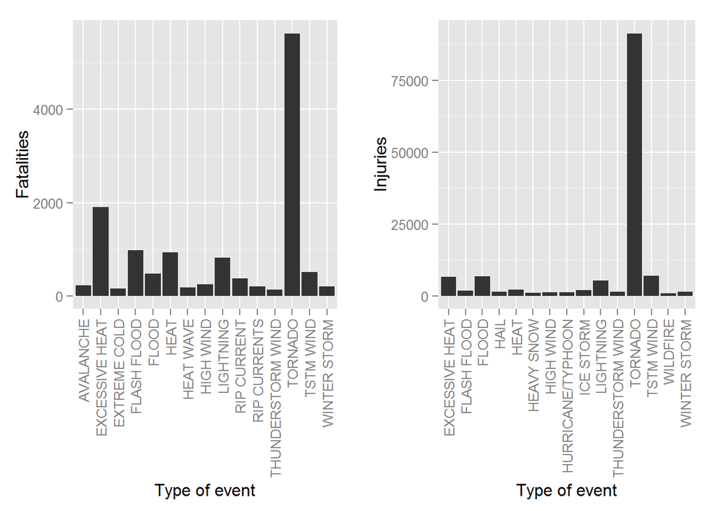

```r
library(ggplot2)
library(gridExtra)

fatplt <- ggplot(topfatalities, aes(EVTYPE, FATALITIES)) + geom_bar(stat = 'identity') + theme(axis.text.x=element_text(angle=90,hjust=1,vjust=0.5)) + xlab('Type of event') + ylab('Fatalities')
injplt <- ggplot(topinjuries, aes(EVTYPE, INJURIES)) + geom_bar(stat = 'identity') + theme(axis.text.x=element_text(angle=90,hjust=1,vjust=0.5)) + xlab('Type of event') + ylab('Injuries')

grid.arrange(fatplt, injplt, ncol=2)
```

This plot tells us that Tornado is way ahead from all the other events by its damage to population health. Excessive heat seems to be in a second position.

### Damage to economics

Let’s now explore economic damage of different weather events. We will use similar bar plot.

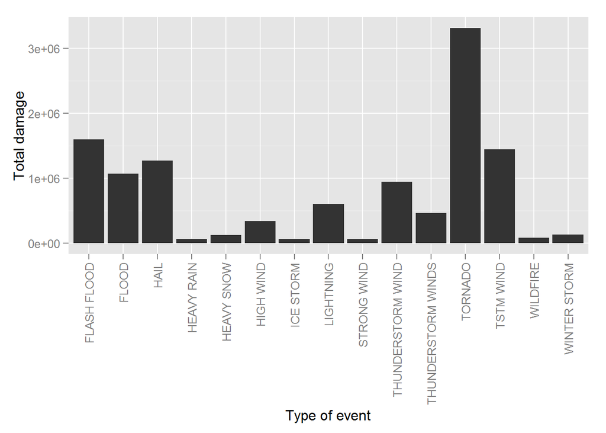

```r
damageplt <- ggplot(topdmg, aes(EVTYPE, DAMAGE)) + geom_bar(stat = 'identity') + theme(axis.text.x=element_text(angle=90,hjust=1,vjust=0.5)) + xlab('Type of event') + ylab('Total damage')
print(damageplt)
```